# 1. Importing relevant libraries and reading dataset

# 12. Generate a dataframe which should include all the information of the top 20 players based on the Overall rating

```python
d_top20
```

|  | ID | Name | Age | Nationality | Overall | Potential | Club | Value | Wage | Preferred Foot | ... | Composure | Marking | StandingTackle | SlidingTackle | GKDiving | GKHandling | GKKicking | GKPositioning | GKReflexes | Release Clause |
| --- | --- | --- | --- | --- | --- | --- | --- | --- | --- | --- | --- | --- | --- | --- | --- | --- | --- | --- | --- | --- | --- |
| 0 | 158023 | L. Messi | 31 | Argentina | 94 | 94 | FC Barcelona | 110500000.0 | 565000.0 | Left | ... | 96.0 | 33.0 | 28.0 | 26.0 | 6.0 | 11.0 | 15.0 | 14.0 | 8.0 | 226500000.0 |
| 1 | 20801 | Cristiano Ronaldo | 33 | Portugal | 94 | 94 | Juventus | 77000000.0 | 405000.0 | Right | ... | 95.0 | 28.0 | 31.0 | 23.0 | 7.0 | 11.0 | 15.0 | 14.0 | 11.0 | 127100000.0 |
| 2 | 190871 | Neymar Jr | 26 | Brazil | 92 | 93 | Paris Saint-Germain | 118500000.0 | 290000.0 | Right | ... | 94.0 | 27.0 | 24.0 | 33.0 | 9.0 | 9.0 | 15.0 | 15.0 | 11.0 | 228100000.0 |
| 3 | 193080 | De Gea | 27 | Spain | 91 | 93 | Manchester United | 72000000.0 | 260000.0 | Right | ... | 68.0 | 15.0 | 21.0 | 13.0 | 90.0 | 85.0 | 87.0 | 88.0 | 94.0 | 138600000.0 |
| 4 | 192985 | K. De Bruyne | 27 | Belgium | 91 | 92 | Manchester City | 102000000.0 | 355000.0 | Right | ... | 88.0 | 68.0 | 58.0 | 51.0 | 15.0 | 13.0 | 5.0 | 10.0 | 13.0 | 196400000.0 |
| 5 | 183277 | E. Hazard | 27 | Belgium | 91 | 91 | Chelsea | 93000000.0 | 340000.0 | Right | ... | 91.0 | 34.0 | 27.0 | 22.0 | 11.0 | 12.0 | 6.0 | 8.0 | 8.0 | 172100000.0 |
| 6 | 177003 | L. Modrić | 32 | Croatia | 91 | 91 | Real Madrid | 67000000.0 | 420000.0 | Right | ... | 84.0 | 60.0 | 76.0 | 73.0 | 13.0 | 9.0 | 7.0 | 14.0 | 9.0 | 137400000.0 |
| 7 | 176580 | L. Suárez | 31 | Uruguay | 91 | 91 | FC Barcelona | 80000000.0 | 455000.0 | Right | ... | 85.0 | 62.0 | 45.0 | 38.0 | 27.0 | 25.0 | 31.0 | 33.0 | 37.0 | 164000000.0 |
| 8 | 155862 | Sergio Ramos | 32 | Spain | 91 | 91 | Real Madrid | 51000000.0 | 380000.0 | Right | ... | 82.0 | 87.0 | 92.0 | 91.0 | 11.0 | 8.0 | 9.0 | 7.0 | 11.0 | 104600000.0 |
| 9 | 200389 | J. Oblak | 25 | Slovenia | 90 | 93 | Atlético Madrid | 68000000.0 | 94000.0 | Right | ... | 70.0 | 27.0 | 12.0 | 18.0 | 86.0 | 92.0 | 78.0 | 88.0 | 89.0 | 144500000.0 |
| 10 | 188545 | R. Lewandowski | 29 | Poland | 90 | 90 | FC Bayern München | 77000000.0 | 205000.0 | Right | ... | 86.0 | 34.0 | 42.0 | 19.0 | 15.0 | 6.0 | 12.0 | 8.0 | 10.0 | 127100000.0 |
| 11 | 182521 | T. Kroos | 28 | Germany | 90 | 90 | Real Madrid | 76500000.0 | 355000.0 | Right | ... | 85.0 | 72.0 | 79.0 | 69.0 | 10.0 | 11.0 | 13.0 | 7.0 | 10.0 | 156800000.0 |
| 12 | 182493 | D. Godín | 32 | Uruguay | 90 | 90 | Atlético Madrid | 44000000.0 | 125000.0 | Right | ... | 82.0 | 90.0 | 89.0 | 89.0 | 6.0 | 8.0 | 15.0 | 5.0 | 15.0 | 90200000.0 |
| 13 | 168542 | David Silva | 32 | Spain | 90 | 90 | Manchester City | 60000000.0 | 285000.0 | Left | ... | 93.0 | 59.0 | 53.0 | 29.0 | 6.0 | 15.0 | 7.0 | 6.0 | 12.0 | 111000000.0 |
| 14 | 215914 | N. Kanté | 27 | France | 89 | 90 | Chelsea | 63000000.0 | 225000.0 | Right | ... | 85.0 | 90.0 | 91.0 | 85.0 | 15.0 | 12.0 | 10.0 | 7.0 | 10.0 | 121300000.0 |
| 15 | 211110 | P. Dybala | 24 | Argentina | 89 | 94 | Juventus | 89000000.0 | 205000.0 | Left | ... | 84.0 | 23.0 | 20.0 | 20.0 | 5.0 | 4.0 | 4.0 | 5.0 | 8.0 | 153500000.0 |
| 16 | 202126 | H. Kane | 24 | England | 89 | 91 | Tottenham Hotspur | 83500000.0 | 205000.0 | Right | ... | 89.0 | 56.0 | 36.0 | 38.0 | 8.0 | 10.0 | 11.0 | 14.0 | 11.0 | 160700000.0 |
| 17 | 194765 | A. Griezmann | 27 | France | 89 | 90 | Atlético Madrid | 78000000.0 | 145000.0 | Left | ... | 87.0 | 59.0 | 47.0 | 48.0 | 14.0 | 8.0 | 14.0 | 13.0 | 14.0 | 165800000.0 |
| 18 | 192448 | M. ter Stegen | 26 | Germany | 89 | 92 | FC Barcelona | 58000000.0 | 240000.0 | Right | ... | 69.0 | 25.0 | 13.0 | 10.0 | 87.0 | 85.0 | 88.0 | 85.0 | 90.0 | 123300000.0 |
| 19 | 192119 | T. Courtois | 26 | Belgium | 89 | 90 | Real Madrid | 53500000.0 | 240000.0 | Left | ... | 66.0 | 20.0 | 18.0 | 16.0 | 85.0 | 91.0 | 72.0 | 86.0 | 88.0 | 113700000.0 |

20 rows × 57 columns

# 13. What is the average "Age" and "Wage" of these top 20 players?

```python
pd.DataFrame(d_top20[['Age','Wage']].mean(), columns=['Average'])
```

|  | Average |
| --- | --- |
| Age | 28.3 |
| Wage | 289700.0 |

# 14. Among the top 20 players based on the Overall rating, which player has the highest wage? Display the name of the player with his wage

```python
d_top20[['Wage']].max()
```

```
Wage    565000.0
dtype: float64
```

```python
d_highest_wage=d_top20.nlargest(1, 'Wage')
d_highest_wage[['Name','Wage']]
```

|  | Name | Wage |
| --- | --- | --- |
| 0 | L. Messi | 565000.0 |

# 15. Generate a dataframe which should include the "Player name", "Club Name", "Wage", and 'Overall rating'

```python
df_4 = pd.DataFrame(df[['Name','Club','Wage','Overall']])
df_4
```

|  | Name | Club | Wage | Overall |
| --- | --- | --- | --- | --- |
| 0 | L. Messi | FC Barcelona | 565000.0 | 94 |
| 1 | Cristiano Ronaldo | Juventus | 405000.0 | 94 |
| 2 | Neymar Jr | Paris Saint-Germain | 290000.0 | 92 |
| 3 | De Gea | Manchester United | 260000.0 | 91 |
| 4 | K. De Bruyne | Manchester City | 355000.0 | 91 |
| ... | ... | ... | ... | ... |
| 18202 | J. Lundstram | Crewe Alexandra | 1000.0 | 47 |
| 18203 | N. Christoffersson | Trelleborgs FF | 1000.0 | 47 |
| 18204 | B. Worman | Cambridge United | 1000.0 | 47 |
| 18205 | D. Walker-Rice | Tranmere Rovers | 1000.0 | 47 |
| 18206 | G. Nugent | Tranmere Rovers | 1000.0 | 46 |

18207 rows × 4 columns

```python
df_4.rename(columns = {'Name':'Player name', 'Club':'Club Name', 'Overall':'Overall rating'}, inplace = True)
df_4
```

|  | Player name | Club Name | Wage | Overall rating |
| --- | --- | --- | --- | --- |
| 0 | L. Messi | FC Barcelona | 565000.0 | 94 |
| 1 | Cristiano Ronaldo | Juventus | 405000.0 | 94 |
| 2 | Neymar Jr | Paris Saint-Germain | 290000.0 | 92 |
| 3 | De Gea | Manchester United | 260000.0 | 91 |
| 4 | K. De Bruyne | Manchester City | 355000.0 | 91 |
| ... | ... | ... | ... | ... |
| 18202 | J. Lundstram | Crewe Alexandra | 1000.0 | 47 |
| 18203 | N. Christoffersson | Trelleborgs FF | 1000.0 | 47 |
| 18204 | B. Worman | Cambridge United | 1000.0 | 47 |
| 18205 | D. Walker-Rice | Tranmere Rovers | 1000.0 | 47 |
| 18206 | G. Nugent | Tranmere Rovers | 1000.0 | 46 |

18207 rows × 4 columns

- i) find the average Overall rating for each club

```python
temp_df=pd.DataFrame(df_4.groupby('Club Name')['Overall rating'].mean()).rename(columns={'Overall rating': 'Average Overall Rating'})
temp_df
```

| Club Name | Average Overall Rating |
| --- | --- |
| SSV Jahn Regensburg | 65.586207 |
| 1. FC Heidenheim 1846 | 65.750000 |
| 1. FC Kaiserslautern | 63.384615 |
| 1. FC Köln | 70.785714 |
| 1. FC Magdeburg | 65.615385 |
| ... | ... |
| Zagłębie Sosnowiec | 60.760000 |
| Çaykur Rizespor | 66.900000 |
| Örebro SK | 60.481481 |
| Östersunds FK | 63.545455 |
| Śląsk Wrocław | 62.200000 |

651 rows × 1 columns

- ii) Display the average overall rating of Top10 Clubs using a plot

```python
df_4_top10=temp_df.nlargest(10, 'Average Overall Rating')
df_4_top10
```

| Club Name | Average Overall Rating |
| --- | --- |
| Juventus | 82.280000 |
| Napoli | 80.000000 |
| Inter | 79.750000 |
| Real Madrid | 78.242424 |
| Milan | 78.074074 |
| FC Barcelona | 78.030303 |
| Paris Saint-Germain | 77.433333 |
| Roma | 77.423077 |
| Manchester United | 77.242424 |
| FC Bayern München | 77.000000 |

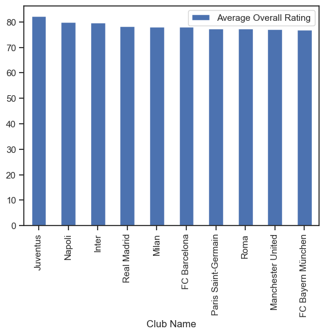

```python
df_4_top10.plot(kind='bar')
plt.show()
```

# 16. What is the relationship between age and individual potential of the player? Visualize the relationship with appropriate plot and Comment on the same

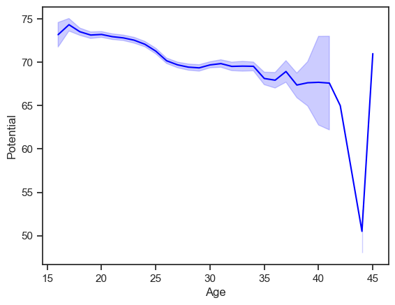

```python
sns.lineplot(x= 'Age', y= 'Potential', data = df, color='blue')
plt.show()
```

- As the age of the players increases, the potential decreases

# 17. Which features directly contribute to the wages of the players?

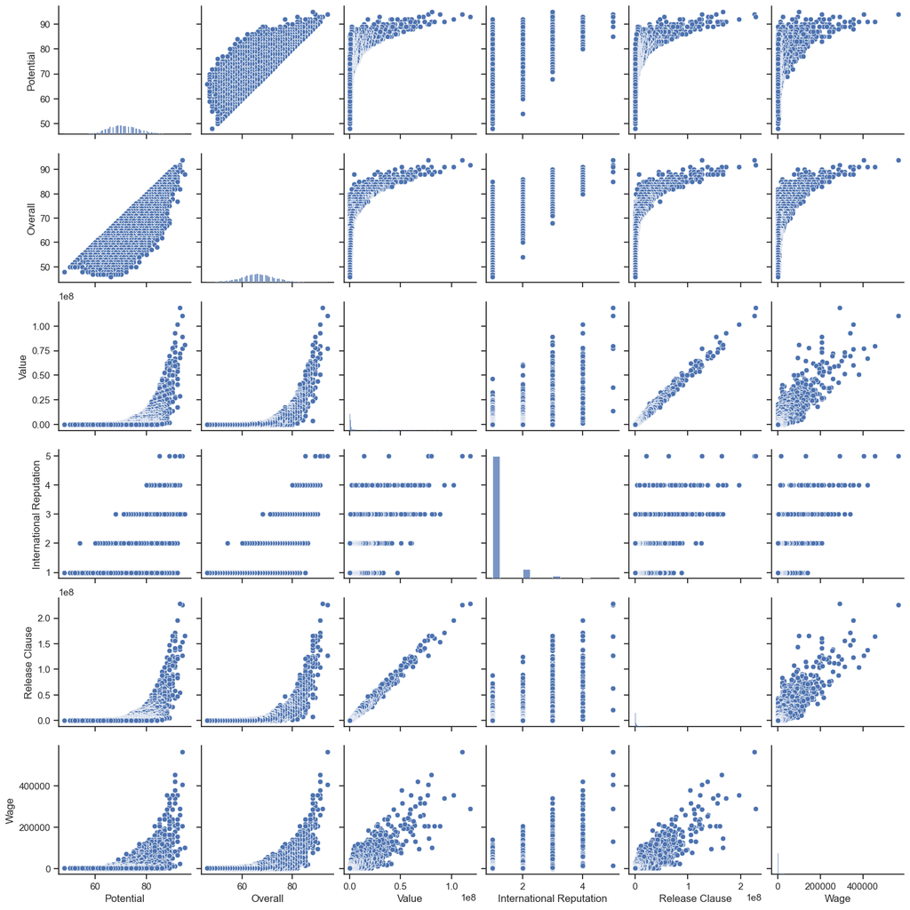

```python
sns.pairplot(df[['Potential','Overall','Value','International Reputation','Release Clause','Wage']])
plt.show()
```

- Wage increases with potential
- Wage increases with Overall rating of a player
- Wage increases with international reputation

# 18. Find the position in the pitch where the maximum number of players play and the position where the minimum number of players play? Display it using a plot

```python
pd.DataFrame(df['Position'].value_counts().sort_values(ascending=False).head(1))
```

|  | Position |
| --- | --- |
| ST | 2152 |

```python
pd.DataFrame(df['Position'].value_counts().sort_values(ascending=True).head(1))
```

|  | Position |
| --- | --- |
| LF | 15 |

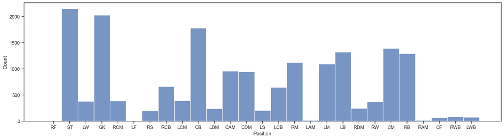

```python
plt.figure(figsize=(20,5))
sns.histplot(df['Position'])
plt.show()
```

# 19. How many players are from the club 'Juventus' and the wage is greater than 200K? Display all the information of such players

```python
df[(df['Club']=='Juventus') & (df['Wage']>200000)]
```

|  | ID | Name | Age | Nationality | Overall | Potential | Club | Value | Wage | Preferred Foot | ... | Composure | Marking | StandingTackle | SlidingTackle | GKDiving | GKHandling | GKKicking | GKPositioning | GKReflexes | Release Clause |
| --- | --- | --- | --- | --- | --- | --- | --- | --- | --- | --- | --- | --- | --- | --- | --- | --- | --- | --- | --- | --- | --- |
| 1 | 20801 | Cristiano Ronaldo | 33 | Portugal | 94 | 94 | Juventus | 77000000.0 | 405000.0 | Right | ... | 95.0 | 28.0 | 31.0 | 23.0 | 7.0 | 11.0 | 15.0 | 14.0 | 11.0 | 127100000.0 |
| 15 | 211110 | P. Dybala | 24 | Argentina | 89 | 94 | Juventus | 89000000.0 | 205000.0 | Left | ... | 84.0 | 23.0 | 20.0 | 20.0 | 5.0 | 4.0 | 4.0 | 5.0 | 8.0 | 153500000.0 |
| 24 | 138956 | G. Chiellini | 33 | Italy | 89 | 89 | Juventus | 27000000.0 | 215000.0 | Left | ... | 84.0 | 93.0 | 93.0 | 90.0 | 3.0 | 3.0 | 2.0 | 4.0 | 3.0 | 44600000.0 |

3 rows × 57 columns

# 20. Generate a data frame containing top 5 players by Overall rating for each unique position

```python
df_top5 = df.groupby(['Position']).apply(lambda x : x.sort_values('Overall',ascending=False).head(5))
df_top5
```

| Position |  | ID | Name | Age | Nationality | Overall | Potential | Club | Value | Wage | Preferred Foot | ... | Composure | Marking | StandingTackle | SlidingTackle | GKDiving | GKHandling | GKKicking | GKPositioning | GKReflexes | Release Clause |
| --- | --- | --- | --- | --- | --- | --- | --- | --- | --- | --- | --- | --- | --- | --- | --- | --- | --- | --- | --- | --- | --- | --- |
| CAM | 17 | 194765 | A. Griezmann | 27 | France | 89 | 90 | Atlético Madrid | 78000000.0 | 145000.0 | Left | ... | 87.0 | 59.0 | 47.0 | 48.0 | 14.0 | 8.0 | 14.0 | 13.0 | 14.0 | 165800000.0 |
|  | 31 | 190460 | C. Eriksen | 26 | Denmark | 88 | 91 | Tottenham Hotspur | 73500000.0 | 205000.0 | Right | ... | 88.0 | 59.0 | 57.0 | 22.0 | 9.0 | 14.0 | 7.0 | 7.0 | 6.0 | 141500000.0 |
|  | 61 | 201942 | Roberto Firmino | 26 | Brazil | 86 | 87 | Liverpool | 53000000.0 | 195000.0 | Right | ... | 87.0 | 60.0 | 64.0 | 42.0 | 8.0 | 11.0 | 9.0 | 6.0 | 10.0 | 104700000.0 |
|  | 66 | 189596 | T. Müller | 28 | Germany | 86 | 86 | FC Bayern München | 45000000.0 | 135000.0 | Right | ... | 83.0 | 44.0 | 41.0 | 44.0 | 6.0 | 7.0 | 11.0 | 14.0 | 14.0 | 74300000.0 |
|  | 74 | 176635 | M. Özil | 29 | Germany | 86 | 86 | Arsenal | 43500000.0 | 190000.0 | Left | ... | 82.0 | 24.0 | 16.0 | 19.0 | 6.0 | 14.0 | 10.0 | 6.0 | 14.0 | 82700000.0 |
| ... | ... | ... | ... | ... | ... | ... | ... | ... | ... | ... | ... | ... | ... | ... | ... | ... | ... | ... | ... | ... | ... | ... |
| ST | 1 | 20801 | Cristiano Ronaldo | 33 | Portugal | 94 | 94 | Juventus | 77000000.0 | 405000.0 | Right | ... | 95.0 | 28.0 | 31.0 | 23.0 | 7.0 | 11.0 | 15.0 | 14.0 | 11.0 | 127100000.0 |
|  | 10 | 188545 | R. Lewandowski | 29 | Poland | 90 | 90 | FC Bayern München | 77000000.0 | 205000.0 | Right | ... | 86.0 | 34.0 | 42.0 | 19.0 | 15.0 | 6.0 | 12.0 | 8.0 | 10.0 | 127100000.0 |
|  | 16 | 202126 | H. Kane | 24 | England | 89 | 91 | Tottenham Hotspur | 83500000.0 | 205000.0 | Right | ... | 89.0 | 56.0 | 36.0 | 38.0 | 8.0 | 10.0 | 11.0 | 14.0 | 11.0 | 160700000.0 |
|  | 23 | 153079 | S. Agüero | 30 | Argentina | 89 | 89 | Manchester City | 64500000.0 | 300000.0 | Right | ... | 90.0 | 30.0 | 20.0 | 12.0 | 13.0 | 15.0 | 6.0 | 11.0 | 14.0 | 119300000.0 |
|  | 36 | 173731 | G. Bale | 28 | Wales | 88 | 88 | Real Madrid | 60000000.0 | 355000.0 | Left | ... | 86.0 | 54.0 | 55.0 | 52.0 | 15.0 | 15.0 | 11.0 | 5.0 | 6.0 | 123000000.0 |

135 rows × 57 columns

# 21. What is the average wage one can expect to pay for the top 5 players in every position?

```python
pd.DataFrame(df_top5['Wage'].groupby('Position').mean()).rename(columns={'Wage': 'Average Wage'})
```

| Position | Average Wage |
| --- | --- |
| CAM | 174000.0 |
| CB | 139600.0 |
| CDM | 217000.0 |
| CF | 47400.0 |
| CM | 130600.0 |
| GK | 192800.0 |
| LAM | 81600.0 |
| LB | 177200.0 |
| LCB | 162000.0 |
| LCM | 184400.0 |
| LDM | 126600.0 |
| LF | 121200.0 |
| LM | 164600.0 |
| LS | 130200.0 |
| LW | 261000.0 |
| LWB | 34200.0 |
| RAM | 45400.0 |
| RB | 155400.0 |
| RCB | 231000.0 |
| RCM | 240800.0 |
| RDM | 105000.0 |
| RF | 148000.0 |
| RM | 131400.0 |
| RS | 132200.0 |
| RW | 202000.0 |
| RWB | 44200.0 |
| ST | 294000.0 |